# Meeting21May

This is a report on the initial findings for energy analysis.

To install the library needed for the script.

```r
library("MASS")
library("lattice")
library("dplyr")
```

As now we have to take all the weather varibles into our model thus we shall now create a new weather file integrating all the the weather files. Combining all the weather files into a single file 2011-11-01 TO 2015-02-28 You can also embed plots, for example:

```r
completeFile <- function(directory,id = 1:4){
  files_list <- list.files(directory,full.names = TRUE)
  dat <- data.frame()
  for( i in id){
    dat <- rbind(dat,read.table(files_list[i],header = TRUE,sep = ",",
                                fill = TRUE))
  }
  dat$timestamp <- as.numeric(as.POSIXct(dat$EST, format="%Y-%m-%d"))
  dat
}
weather <- completeFile(directory = D,id = 1:4)
weather <- select(weather,-1)
weather <- weather[,c(23,1,2,3,4,5,6,7,8,9,10,11,12,13,14,15,16,17,18,19,20,21,22)]
colnames(weather)
```

```
##  [1] "timestamp"                 "Max.TemperatureF"
##  [3] "Mean.TemperatureF"         "Min.TemperatureF"
##  [5] "Max.Dew.PointF"            "MeanDew.PointF"
##  [7] "Min.DewpointF"             "Max.Humidity"
##  [9] "Mean.Humidity"             "Min.Humidity"
## [11] "Max.Sea.Level.PressureIn"  "Mean.Sea.Level.PressureIn"
## [13] "Min.Sea.Level.PressureIn"  "Max.VisibilityMiles"
## [15] "Mean.VisibilityMiles"      "Min.VisibilityMiles"
## [17] "Max.Wind.SpeedMPH"         "Mean.Wind.SpeedMPH"
## [19] "Max.Gust.SpeedMPH"         "PrecipitationIn"
## [21] "CloudCover"                "Events"
## [23] "WindDirDegrees"
```

As we know that the weather data comes from Boston Logan Airport thus the temperature reading as well as the need are quite different. Airport is situated near the coast and university situated away thus we need to eliminate some parameters form the model which we assume must not have affected the energy consumption. Eliminating Wind Parameters For start we are eliminating the Wind parameters as the values differ considerably when we compare notheastern univeristy to airport

```r
colnames(weather[,c(0,14:19)])
```

```
## [1] "Max.VisibilityMiles"  "Mean.VisibilityMiles" "Min.VisibilityMiles"
## [4] "Max.Wind.SpeedMPH"    "Mean.Wind.SpeedMPH"   "Max.Gust.SpeedMPH"
```

```r
weather <- select(weather,-(14:19))
colnames(weather)
```

```
##  [1] "timestamp"                 "Max.TemperatureF"
##  [3] "Mean.TemperatureF"         "Min.TemperatureF"
##  [5] "Max.Dew.PointF"            "MeanDew.PointF"
##  [7] "Min.DewpointF"             "Max.Humidity"
##  [9] "Mean.Humidity"             "Min.Humidity"
## [11] "Max.Sea.Level.PressureIn"  "Mean.Sea.Level.PressureIn"
## [13] "Min.Sea.Level.PressureIn"  "PrecipitationIn"
## [15] "CloudCover"                "Events"
## [17] "WindDirDegrees"
```

We need to find the underlying behind the parameter precipitation for which come values are 0. Indicating that at those days we had no precipitation and some values are T. Thus we still need to get a good picture from where we got the data from. Hence we are removing the PrecipitationIn from the data frame. Eliminating CloudCover/Events/WindDirDegree Parameters

```r
weather <- select(weather,-14)

weather <- select(weather,-(14:16))
colnames(weather)
```

```
##  [1] "timestamp"                 "Max.TemperatureF"
##  [3] "Mean.TemperatureF"         "Min.TemperatureF"
##  [5] "Max.Dew.PointF"            "MeanDew.PointF"
##  [7] "Min.DewpointF"             "Max.Humidity"
##  [9] "Mean.Humidity"             "Min.Humidity"
## [11] "Max.Sea.Level.PressureIn"  "Mean.Sea.Level.PressureIn"
## [13] "Min.Sea.Level.PressureIn"
```

We still need to define either we are working for HDD or CDD i.e. either heating energy consumption or cooling energy consumption Thus we can actually convert the temperature to HDD and CDD values which will help us to work with temoerature.

HDD To calculate HDD, take the average of a day’s high and low temperatures and subtract from 65. For example, if the day’s average temperature is 50o F, its HDD is 15. If every day in a 30-day month had an average temperature of 50o F, the month’s HDD value would be 450 (15 x 30).source -wikipedia

Now we will add a new predictable variable HDD(Heating Degree Days) for all the all the values of the timestamp. 65 F will be the cutoff temperature. If the mean temperature is above the cutoff we dont have heating degree days that day.

```r
weather$HDD <- abs(weather$Mean.TemperatureF - 65)
# Thus we can either ignore the HDD values. Topic for discussion.
# We can take either of the HDD or CDD(Cooling Degree Day) depending
# we are investigating heating or cooling energy consumption).

# If the mean temperature is above 65, there are no heating degree
# days that day.
# Extracting the values which have the mean temp is below 65
weatherHDD <- filter(weather,
                     (weather$Mean.TemperatureF < 65))
```

# —– Oldest Building / Heating Consumption —–

```r
min(building.DB$Year.Acquired)
```

```
## [1] 1898
```

```r
# Bid value of the oldest building
id <- select(filter(building.DB, building.DB$Year.Acquired == min(building.DB$Year.Acquired)),1)
id # Bid = 13 (Fenway Center)
```

```
##   bID
## 1  13
```

```r
dataFrame_1 <- data.frame(sID = c())
dataFrame_1
```

```
## data frame with 0 columns and 0 rows
```

```r
dataFrame_1 <- rbind(dataFrame_1,
                     filter(measureDB_serial,
                            measureDB_serial$sID == id[1,1]))

# If we have some entries as 0 we shall convert those values to NA
dataFrame_1[dataFrame_1 == 0] <- NA
dataFrame_1 <- na.omit(dataFrame_1)
dataFrame_1 <- select(dataFrame_1,1,3)
# Merge the data of weather and value and eliminating the NA values
weather_1 <- select(weatherHDD,1,14)
buildingWeather <- merge(weather_1,dataFrame_1,all = TRUE)
buildingWeather[buildingWeather == 0] <- NA
buildingWeather <- na.omit(buildingWeather)
```

We can also use clustering methods here such as hierarchical clustring to get a better sence of the points and the data.

# —– Linear Model Fitting —–

```r
fit1 <- lm(value ~ HDD,data = buildingWeather)
summary(fit1)
```

```
##
## Call:
## lm(formula = value ~ HDD, data = buildingWeather)
##
## Residuals:
##     Min      1Q  Median      3Q     Max
## -13.801  -8.410  -4.718   2.756 124.841
##
## Coefficients:
##             Estimate Std. Error t value Pr(>|t|)
## (Intercept) 25.92618    1.66743  15.549   <2e-16 ***
## HDD          0.06821    0.06247   1.092    0.275
## ---
## Signif. codes:  0 '***' 0.001 '**' 0.01 '*' 0.05 '.' 0.1 ' ' 1
##
## Residual standard error: 16.98 on 447 degrees of freedom
## Multiple R-squared:  0.00266,    Adjusted R-squared:  0.0004288
## F-statistic: 1.192 on 1 and 447 DF,  p-value: 0.2755
```

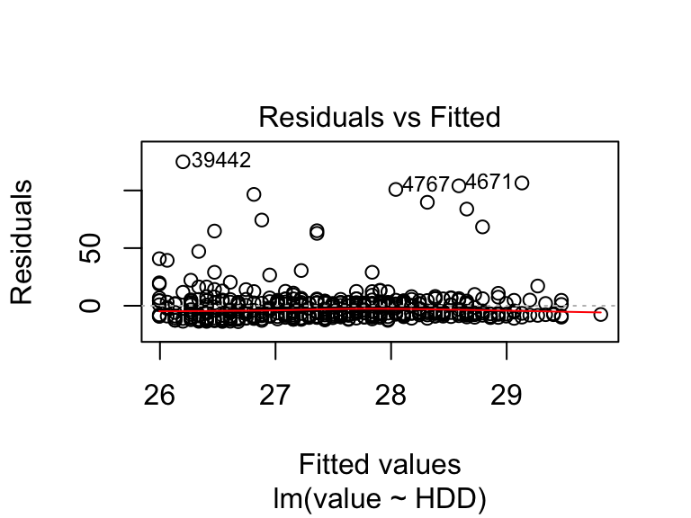

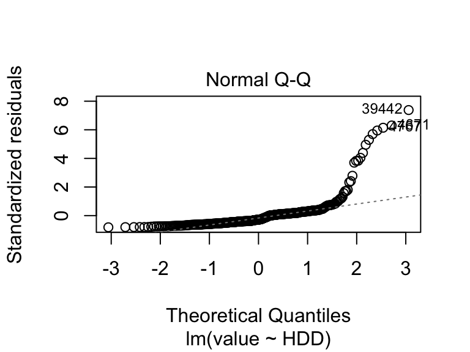

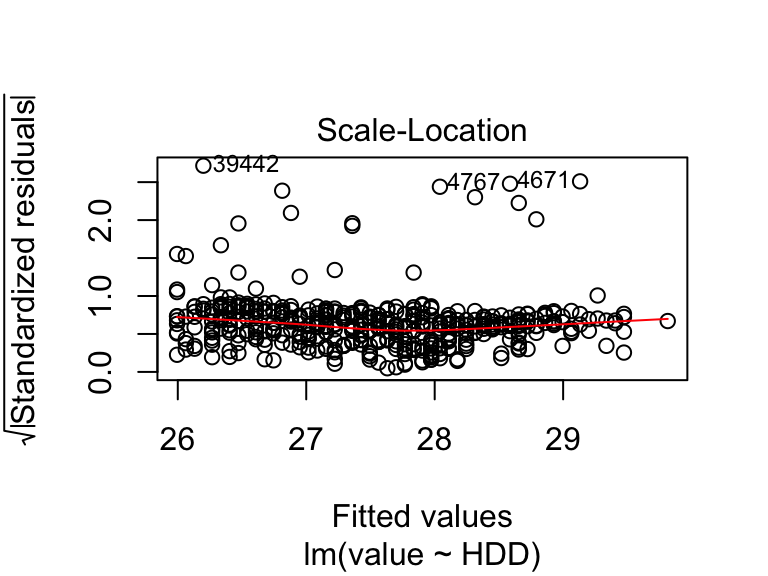

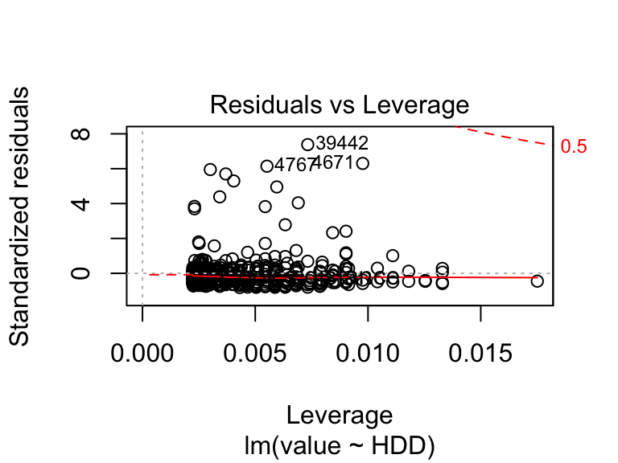

```r
plot(fit1)
```

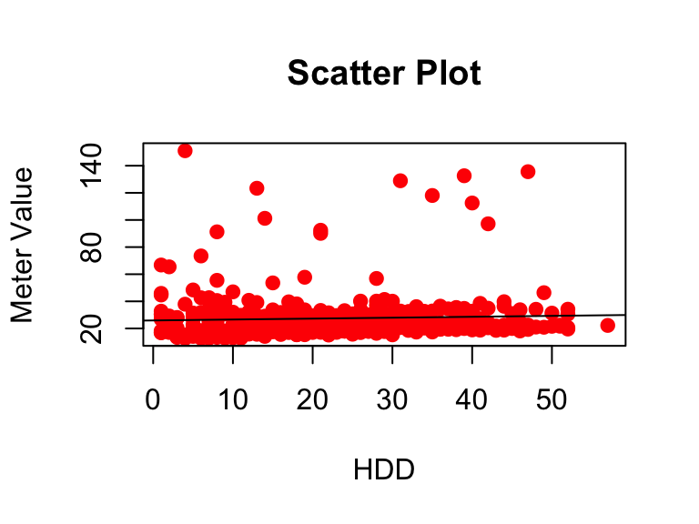

```r
plot(buildingWeather$HDD,buildingWeather$value,main = "Scatter Plot",xlab = "HDD",ylab = "Meter Value", col = "red",pch = 19)
abline(fit1)
```

# —– Boxcox transformation —–

Performing transformation to the predictor and response variable for which we can use the boxcox transformation

```r
# bx <- boxcox(fit1,lambda = seq(-2,2,1/10),plotit = FALSE)
# lambda <- bx$x
# lik <- bx$y
# boxcoxTable <- cbind(lambda,lik)
# boxcoxTable
# boxcoxTable[order(-lik),] # -2.00000000

fit2 <- lm((value)^(-2.00000000) ~ HDD,data = buildingWeather)
summary(fit2)
```

```
##
## Call:
## lm(formula = (value)^(-2) ~ HDD, data = buildingWeather)
##
## Residuals:
##        Min         1Q     Median         3Q        Max
## -0.0024588 -0.0009200 -0.0001140  0.0007778  0.0036985
##
## Coefficients:
##               Estimate Std. Error t value Pr(>|t|)
## (Intercept)  2.599e-03  1.194e-04   21.76  < 2e-16 ***
## HDD         -2.421e-05  4.475e-06   -5.41 1.03e-07 ***
## ---
## Signif. codes:  0 '***' 0.001 '**' 0.01 '*' 0.05 '.' 0.1 ' ' 1
##
## Residual standard error: 0.001216 on 447 degrees of freedom
## Multiple R-squared:  0.06146,    Adjusted R-squared:  0.05936
## F-statistic: 29.27 on 1 and 447 DF,  p-value: 1.028e-07
```

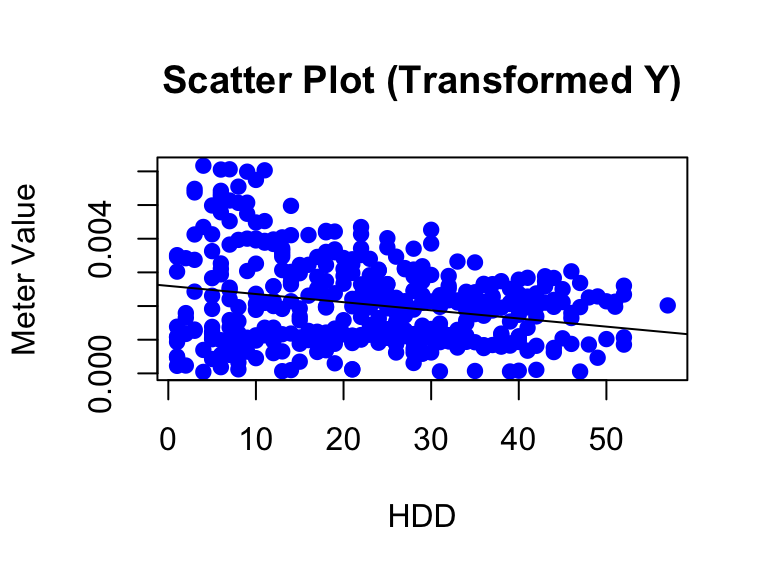

```r
plot(buildingWeather$HDD,(buildingWeather$value)^(-2.00000000),
     main = "Scatter Plot (Transformed Y)",xlab = "HDD",
     ylab = "Meter Value", col = "blue", pch = 19)
abline(fit2)
```

```r
# Scaling of the predictable variable HDD was not effective.
```

# —– Linear Model Fitting / Working with Weekdays Consumption——

```r
library("base")
# Creating a new column which will represent the day for the given
# time stamp so what we can work on the values for weekdays energy
# as the building we are aiming to analyse is the Student Services.
buildingWeather$Days <- weekdays(as.POSIXct(buildingWeather$timestamp, origin="1970-01-01"))
buildingWeatherWeekdays <- filter(buildingWeather,
                                  buildingWeather$Days == "Monday" |
                                    buildingWeather$Days == "Tuesday"|
                                    buildingWeather$Days == "Wednesday" |
                                    buildingWeather$Days == "Thursday" |
                                    buildingWeather$Days == "Friday")
buildingWeatherWeekends <- filter(buildingWeather,
                                  buildingWeather$Days == "Saturday"|
                                    buildingWeather$Days == "Sunday")
# Now we have two data frames for weekdays and weekends and thus
# we can work on them separetely.
```

# – Weekdays—

```r
fitweekdays <- lm(buildingWeatherWeekdays$value ~
                    buildingWeatherWeekdays$HDD)
summary(fitweekdays)
```

```
##
## Call:
## lm(formula = buildingWeatherWeekdays$value ~ buildingWeatherWeekdays$HDD)
##
## Residuals:
##     Min      1Q  Median      3Q     Max
## -15.282  -7.925  -4.099   3.027 123.026
##
## Coefficients:
##                             Estimate Std. Error t value Pr(>|t|)
## (Intercept)                 28.15703    1.80593  15.591   <2e-16 ***
## buildingWeatherWeekdays$HDD -0.03567    0.06688  -0.533    0.594
## ---
## Signif. codes:  0 '***' 0.001 '**' 0.01 '*' 0.05 '.' 0.1 ' ' 1
##
## Residual standard error: 16.19 on 322 degrees of freedom
## Multiple R-squared:  0.0008826,  Adjusted R-squared:  -0.00222
## F-statistic: 0.2844 on 1 and 322 DF,  p-value: 0.5942
```

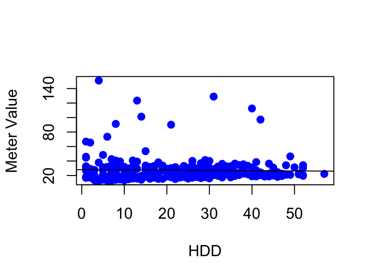

```r
plot(buildingWeatherWeekdays$HDD,buildingWeatherWeekdays$value,
     xlab = "HDD",ylab = "Meter Value", col = "blue", pch = 19)
abline(fitweekdays)
```

# Boxcox transformation on Y

```r
# bx <- boxcox(fitweekdays,lambda = seq(-2,2,1/10),plotit = TRUE)
# lambda <- bx$x
# lik <- bx$y
# boxcoxTable <- cbind(lambda,lik)
# boxcoxTable[order(-lik),]  # -0.94949495

fitweekdaysBoxcox <- lm((buildingWeatherWeekdays$value)^(-0.94949495) ~
                          buildingWeatherWeekdays$HDD)
summary(fitweekdaysBoxcox)
```

```
##
## Call:
## lm(formula = (buildingWeatherWeekdays$value)^(-0.94949495) ~
##     buildingWeatherWeekdays$HDD)
##
## Residuals:
##       Min        1Q    Median        3Q       Max
## -0.044304 -0.011060  0.001648  0.011249  0.036477
##
## Coefficients:
##                               Estimate Std. Error t value Pr(>|t|)
## (Intercept)                  5.341e-02  1.705e-03  31.331   <2e-16 ***
## buildingWeatherWeekdays$HDD -1.446e-04  6.313e-05  -2.291   0.0226 *
## ---
## Signif. codes:  0 '***' 0.001 '**' 0.01 '*' 0.05 '.' 0.1 ' ' 1
##
## Residual standard error: 0.01528 on 322 degrees of freedom
## Multiple R-squared:  0.01604,    Adjusted R-squared:  0.01298
## F-statistic: 5.249 on 1 and 322 DF,  p-value: 0.02261
```

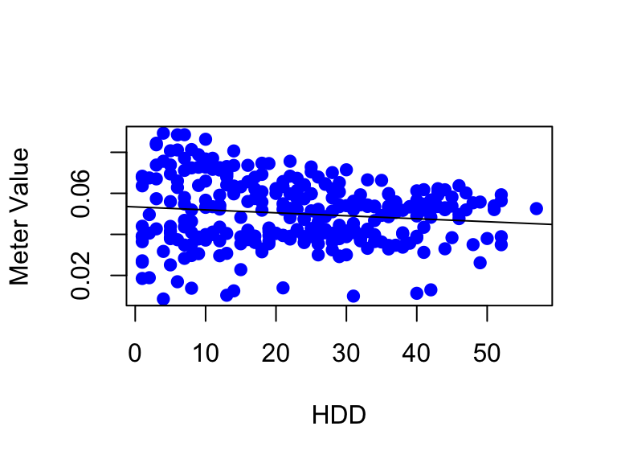

```r
plot(buildingWeatherWeekdays$HDD,(buildingWeatherWeekdays$value)^(-0.94949495),
     xlab = "HDD",ylab = "Meter Value", col = "blue", pch = 19)
abline(fitweekdaysBoxcox)
```

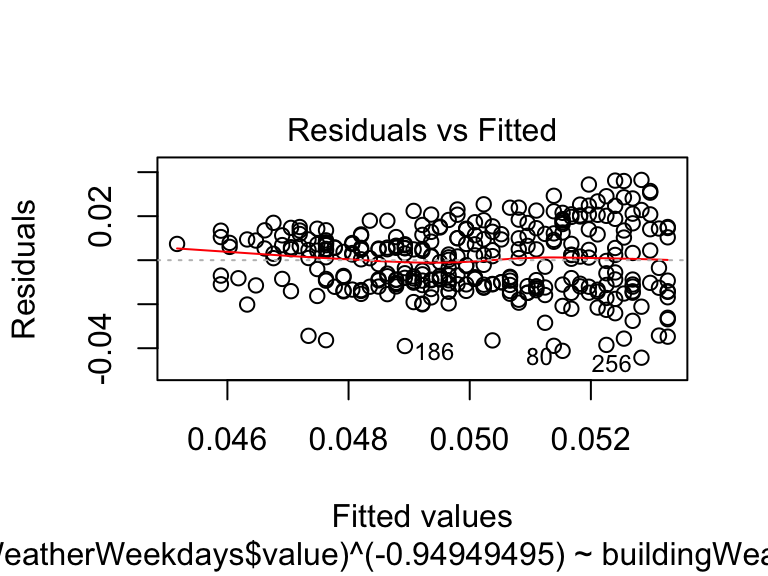

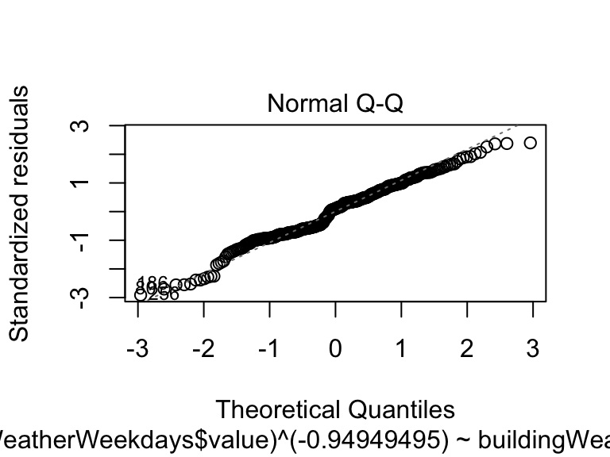

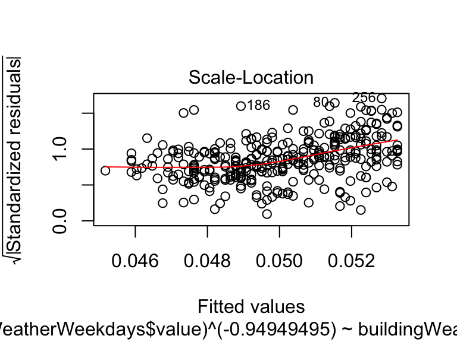

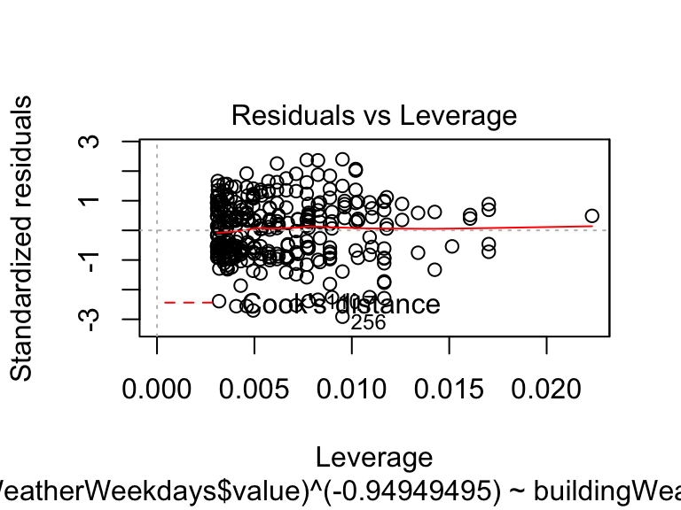

```r
plot(fitweekdaysBoxcox)
```

```r
# Thus we can see non constant variance. Hence we can use the
# weighted regression analysis.
```